# Reproducible Workflow

Loading and eye-balling a dataset

Author

Affiliation

Daniela Palleschi

Humboldt-Universität zu Berlin

Published

April 12, 2023

# Set-up

```r
knitr::opts_chunk$set(eval = T, # evaluate = T for REPRODUCIBLE analyses
                      echo = T, # 'print code chunk?'
                      message = F, # print messages?
                      error = T, # render even if errors encountered?
                      warning = F) # print warnings?
```

```r
library(beepr) # beeps when code runs or fails
library(rbbt) # zotero plugin
```

**beep code**

```r
## play sound if error encountered
### from: https://sejohnston.com/2015/02/24/make-r-beep-when-r-markdown-finishes-or-when-it-fails/
options(error = function(){    # Beep on error
  beepr::beep(sound = "wilhelm")
  Sys.sleep(2) #
  }
 )
## and when knitting is complete
.Last <- function() {          # Beep on exiting session
  beepr::beep(sound = "ping")
  Sys.sleep(6) # allow to play for 6 seconds
  }
```

**rbbt code**

```r
# Create references.json file based on the citations in this script:
# 1. make sure you have 'bibliography: references/references.json' in the YAML
# 2. create a new folder called 'references'
# 3. run:
rbbt::bbt_update_bib("_workflow.qmd")
```

# Workflow bare minimum

- self-contained project
  - everything available in one folder
  - e.g., RProjects
- README file
  - a markdown (.md) file
  - describing the folder/analysis structure

Winter (2019)

# RProjects

- a folder containing
  - an `.RProj` file (which opens RStudio)
  - all folders/files required for a project
- `File > New Project > New Directory > New Project > New Project > Create Project`

## README

- to create an `.md` file: `File > New File > Markdown File`
- create informative heading
  - describe project purpose
  - describe folders/scripts as they currently are
- save/Preview as `README.md` in the project folder

## `here`

- `here` package
  - will always access the project folder
  - try running `here()` from within a project; what’s the output?

## Project folder structure

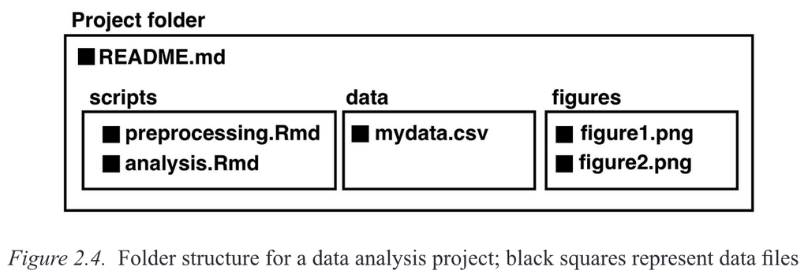

Image source: Winter (2019)

# Reproducible code

- is located within a project
  - which also contains all relevant data/files
- runs linearly (from top to bottom)
  - loads all required packages at the top
  - uses file paths relative to its project
  - is created/edited after running `Session > Restart R`
- at the very least, ends with a section (e.g., `# Session Info`) containing `sessionInfo()`
  - but other options: `renv` package, `targets` package, `docker` for environment containers

# Checklist

**RProject** + `.RProj` + `README.md` + `data/` + `notes/` (a folder for your qmd files)

**Scripts** (`.qmd`/`.Rmd`) + load libraries at beginning + `sessionInfo()` at the end + chunks run linearly (top-to-bottom)

[session information not shown]

# References

Winter, B. (2019). *Statistics for Linguists: An Introduction Using R*. Routledge. https://doi.org/10.4324/9781315165547